# Homework #1

4. Use the graphical method to solve the dual model (an approximation is fine, you can type the answer in your R Notebook if you’re not comfortable graphing)

```
integer(0)
```

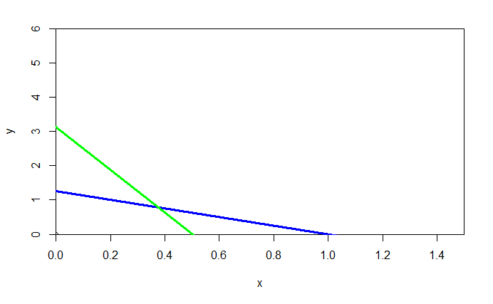

```r
library(ggplot2)
# min: 1245x + 300y
# st: 5x + 4y <= 5
#     50x + 8y <= 25
# begin plot
plot(x = 0, y = 0, xlim = c(0,1.5), ylim = c(0,6), xlab = "x", ylab = "y",
     xaxs = 'i', yaxs = 'i') +
abline(a = 1.25, b = -1.25, col = "blue", lwd = 3) +
abline(a = 3.125, b = -6.25, col = "green", lwd = 3)
```

Approximate point: (0.39, 0.80)

5. Interpret the dual results

There is a 0.39 increase in profit for every one unit increase in Inputs. There is a 0.80 increase in profit for every one unit increase in Water.

It is common for the parameters of the model to be uncertain. As such, it is good to be aware of “tipping” points in the model, where small changes in parameters can lead to dramatic changes in the model solution. Using your graph of the primal problem in part (b) above, perform the following sensitivity analysis:

```
numeric(0)
```

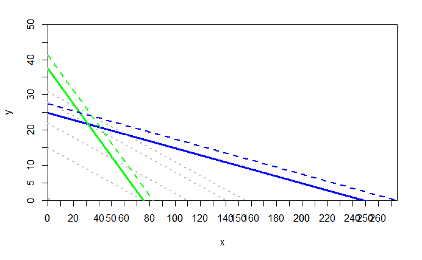

```r
library(ggplot2)
# max: 5x + 25y
# st: 5x + 50y <= 1245
#     4x + 8y <= 300
# begin plot
plot(x = 0, y = 0, xlim = c(0,275), ylim = c(0,50), xlab = "x", ylab = "y",
axis(side = 1, at = seq(0, 275, by = 10)) +
axis(side = 2, at = seq(0, 50, by = 5)) +
abline(a = 1245/50, b = -.1, col = "blue", lwd = 3) +
abline(a = 300/8, b = -.5, col = "green", lwd = 3) +
abline(a = 15, b = -(5/25), col = "grey", lty = "dotted", lwd = 2) +
abline(a = 28, b = -(5/25), col = "grey", lty = "dotted", lwd = 2) +
# dual/shadow + 10%
abline(a = 1369.5/50, b = -.1, col = "blue", lty = 2, lwd = 2) +
abline(a = 330/8, b = -.5, col = "green", lty = 2, lwd = 2) +
abline(a = 31, b = -(5/25), col = "grey", lty = "dotted", lwd = 2)
```

```r
# # decrease in rhs by 10%
# abline(a = 1120.5/50, b = -.1, col = "black", lty = 2, lwd = 2) +
# abline(a = 270/8, b = -.5, col = "grey", lty = 2, lwd = 2)
```

6. What changes in the objective function parameters would change the solution in (b)

Changes outside of the approximate range of 25-37 for the y value and 75-250 for the x value will have an effect on the solution because the optimal point will no longer fall in its current position.

7. What changes in the right hand side constraints would change the solution in (b)

8. What changes in the constraint parameters would change the solution in (b)

Relaxing the constraint by 10% moves our optimal point upwards increasing. Changing the constraint parameters changes the slope.

1. Program the problem from above and find the solution

```r
## setup enviroment and libraries
library(lpSolve)
library(lpSolveAPI)
lp.control(lpP5, sense = "max")
```

[output not shown]

[output cut: 8 more lines]

[output not shown]

```r
set.objfn(lpP5, c(5,25))
# setup constraint matrix
add.constraint(lpP5, c(5,50), "<=", 1245)
add.constraint(lpP5, c(4,8), "<=", 300)
dimnames(lpP5) <- list(c("Inputs", "Water"),
                       c("Grains", "Vegetables"))
# check model
lpP5
```

```
Model name:
              Grains  Vegetables
Maximize           5          25
Inputs             5          50  <=  1245
Water              4           8  <=   300
Kind             Std         Std
Type            Real        Real
Upper            Inf         Inf
Lower              0           0
```

```r
# solve model
solve(lpP5)
```

```
[1] 0
```

```r
# variables
get.variables(lpP5)
```

```
[1] 31.50 21.75
```

```r
# constraints
get.constraints(lpP5)
```

```
[1] 1245  300
```

```r
# objective variable
get.objective(lpP5)
```

[output not shown]

Conclusion:

To maximize profits the farmer should use 21.75 acres for vegetables and 31.50 acres for grains. The max profit the farmer should expect is $701.25.

10. Find the dual values and interpret them

```r
get.dual.solution(lpP5)
```

```
[1] 1.00000 0.37500 0.78125 0.00000 0.00000
```

11. Find the sensitivity range and compare to what you found in parts (f) and (g)

```r
library(lpSolve)
library(lpSolveAPI)
ps <- get.primal.solution(lpP5)
obj_sa <- get.sensitivity.obj(lpP5)
rhs_sa <- get.sensitivity.rhs(lpP5)
n <- length(get.variables(lpP5))
m <- length(get.constr.type(lpP5))
ov <- paste0("objective value = ", ps[1])
obj_fn <- get.objective(lpP5)
sa_tab <- rbind(ps[2:(n + m + 1)],
                c(round(rhs_sa$duals[1:m], 2), obj_fn),
                round(c(rhs_sa$dualsfrom[1:m], obj_sa$objfrom), 2),
                round(c(rhs_sa$dualstill[1:m], obj_sa$objtill), 2))
```

```
number of columns of result is not a multiple of vector length (arg 2)
```

```r
colnames(sa_tab) <- c(rownames(lpP5), colnames(lpP5))
rownames(sa_tab) <- c("solution", "duals/coef", "Sens From", "Sens Till")
ov
```

```
[1] "objective value = 701.25"
```

```r
as.table(sa_tab)
```

```
            Inputs   Water  Grains Vegetables
solution   1245.00  300.00   31.50      21.75
duals/coef    0.37    0.78
Sens From   375.00  199.20    2.50      10.00
Sens Till  1875.00  996.00   12.50      50.00
```

For our constraints the sensitivy range for Inputs is 375 to 1875. The range for Water is from 199.20 to 996.00. For our objective function the range for Grains is from 2.50 to 12.50, and the range for Vegetables is from 10 to 50. Compared to much parts (f) and (g) these are much more precise ranges.